# Katana Crib Sheet

Philip J Clare

20 July 2020

# Katana

## Broad overview of Katana

Katana is a distributed high performance cluster computer. It is made up of a large number of relatively high performance ‘nodes’ (generally with 32 or 40 cores each), linked together by a ‘master’ node which schedules and distributes jobs.

There are two ways to run jobs on Katana:

1. Interactively  
   This means running a job like you would on a normal PC, with a live runtime, and the ability to write and run code as you go.
2. Batch job  
   This is a job run from a pre-written script, that does not require any intervention.

## Parallel Processing

The main advantage of Katana is parallel processing. Each individual core on Katana nodes are not particularly different to a standard PC (some may be faster, but some are slower). But Katana allows jobs to potentially use dozens of cores simultaneously.

There are two main ways to parallelise a job using a cluster computer:

1. In-program parallelisation, for example using the R base package ‘parallel’. It is worth noting that, while a multi-core version of Stata exists, it is NOT installed on Katana, so Stata on Katana is limited to single core processes (it is also not a very recent version).
2. Splitting the job across nodes using an array job which calls runs the same script multiple times (potentially with parameters) There are advantages and disadvantages to each, but the main ones are:

|  | In-program parallelisation | Array jobs |
| --- | --- | --- |
| Advantages | Job script can be written and tested on local PC – only major difference is the number of cores available. | Jobs can be split into smaller individual jobs, which can be distributed across nodes, using any available cores as they come up. |
| Disadvantages | Requires all the cores to be on the same node, which can affect wait times (and potentially viability of the job). | Requires more setup, because job script has to be ‘generic’. Can sometimes take longer because of overcomputing (see below). |

## What is it good for?

Katana (and cluster computers more generally) are most effective for jobs that can be divided into similar or identical parts, and then recombined at the end. Some examples of situations that can be made more efficient by cluster computing are: * Multiple imputation to deal with missing data. For example, with a dataset with about 20% missing data, you might want to make 20 imputed datasets. Usually, this would be done sequentially – create imputation #1, then move onto #2 and so on. * Analysis of clustered data using mixed effects models, where a different model is conducted for each of a number of outcomes, but the predictor variables are the same across. * Cross-validation in machine learning – where data is randomly split into different sets, and the same machine learning algorithm is run on each set. In each of these, the tasks being performed are very similar or even identical apart from ‘randomness’. Thus, the task can be sped up by running each task simultaneously on a different processing core.

## Using Katana

For the basics of running jobs and using Katana, you can check out the Katana User Documentation: https://unsw-restech.github.io/restech-docs/index.html

However, there are some things that are worth considering in addition to the basics of getting a job running:

- Run smaller tests first. In addition to making sure there are no issues with your code, this can also help give you a better idea of exactly how many resources to request. If you ask for 100gb of memory, but the end-of-job email says the job only used 30gb, you can safely lower your request. This will make it easier for the scheduler to fit in your job.
- Think carefully about the best way to split the job up to make it most efficient.
- Be careful of replicability/random seeds. A lot of processes (eg multiple imputation) use random seeds to ensure both (quasi)randomness and replicability. This means that if you split the job up across nodes, you need to be very careful about how seeds are set to ensure that the random processes are independent but replicable.

## Examples

I will show two examples of the use of Katana for parallel processing. Code for both examples is available on [Github](https://github.com/philipclare/katana).

### In-program Parallelisation

R has a range of parallel processing options, including the base package ‘parallel’, which contains a number of functions designed for parallel processing. In addition, there are quite a few R packages that are designed to work in parallel.

One example of this is multiple imputation via parallel processing, using the function ‘parlmice’ from the package ‘miceadds’. This function works similarly to the function ‘mice’, performing multiple imputation using a range of different possible imputation methods, but in parallel rather than serial. However, generic parallel wrappers are also available- for example, the function ‘parLapply’ is a parallel extension of ‘lapply’, designed to work with clusters defined by ‘parallel’ (see: [Package ‘parallel’](https://stat.ethz.ch/R-manual/R-devel/library/parallel/doc/parallel.pdf)). Similarly, the function ‘foreach’ can be applied in parallel using the binary operator %dopar% (see: [Getting Started with doParallel and foreach](https://cran.r-project.org/web/packages/doParallel/vignettes/gettingstartedParallel.pdf)).

This kind of parallel processing can also be used on a standard workstation (although parallel processing is somewhat less efficient in Windows than *nix. Thus the primary advantage of Katana for in-program parallelisation is the number of cores available on Katana nodes (up to 40).

Example 1 shows an example of in-program parallelisation to perform a relatively simply imputation using parlmice.

#### Example 1 PBS Script

```r
#!/bin/bash

#PBS -N IMPUTATION_EXAMPLE
#PBS -l select=1:ncpus=10:mem=40gb
#PBS -l walltime=12:00:00
#PBS -M p.clare@unsw.edu.au
#PBS -m ae
#PBS -j oe
#PBS -k oed

cd $PBS_O_WORKDIR

module purge
module add R/3.6.1

Rscript /home/z3312911/examples/E1-Imputation.R
```

#### Example 1 R Code

```r
##############################################################################
##
## Katana example 1
## Multiple imputation using 'parlmice'
## Date: 30 June 2020
##
##############################################################################
# 1. Setup Environment
#-----------------------------------------------------------------------------

# 1.1 Specify paths
.libPaths("/home/z3312911/RPackages") # Change to folder where R packages can be saved
workdir <- "/home/z3312911/examples/" # Change to folder where job files are saved

# 1.2 Check libraries, install missing packages, update old packages, and then load packages
libs <- c("mice","miceadds","parallel")
install <- !libs %in% installed.packages() | libs %in% old.packages()
if (any(install)) {
  install.packages(libs[install])
}
lapply(libs, library, character.only = TRUE)

# 1.3 Set seed
set.seed(56188)

##############################################################################
# 2.Load data
#-----------------------------------------------------------------------------

data(nhanes)

##############################################################################
# 3. Define Imputation Paramaters
#-----------------------------------------------------------------------------

m <- 40 # Number of imputations
maxit <- 100; # Number of mice iterations
cluster.seed <- 23771 # Needs to be set within function for parallel computing
numcores <- as.numeric(Sys.getenv('NCPUS')) # Defined from cluster environment variable
n.imp.core = m/numcores # number of imputations per core
cl.type = "FORK" # Could be PSOCK for Windows based systems

##############################################################################
# 4. Imputation
#-----------------------------------------------------------------------------

# 3.3 Parallel imputation using parlmice and randomforests
imp_mice <- parlmice(data=nhanes,
                     cluster.seed=cluster.seed,
                     n.core=numcores,
                     n.imp.core=n.imp.core,
                     maxit=maxit,
                     method="rf",
                     cl.type=cl.type)
imp_mice <- mids2datlist(imp_mice)

##############################################################################
# 5. Save
# 5.1 Save imputation
save(imp_mice, file=paste0(workdir,"imputed-mice.RData"))
```

### Array job

For very large jobs (or jobs that do not use R), in-program parallel processing is often simply not possible. For example, take cross-validation of a machine learning algorithm, which might need to be run 1000 times, and take several hours to run each time. Even using all 40 CPUS on the NDARC node, that job could take weeks to run. However, it may be possible to split the processes so that each iteration runs separately, on as many available CPUs at a time. In reality, Katana will allow you to use up to 150 cores at a time – far more than the 40 available on any given node.

This does require some work. The code itself must be written to be ‘generic’ – that is, the only difference between the iterations is something that can be passed to the code via a parameter. Consider a very simple example, where you want to run the same analysis on 1000 different datasets – in that case, the code itself would be the same, and only the number of the dataset to load would differ – a parameter which can be defined by Katana and passed to the program script.

Note that this can create difficulties – in particular, with any operation that relies on random numbers. Take, for example, a Monte-Carlo simulation – where the code is run numerous times, and the only difference between iterations is the random number generate ‘state’, which means that numbers are as random and independent as possible. It is not a trivial matter to set seeds in such a way as to guarantee that both 1) the numbers generated by each iteration are replicable, and 2) that the numbers generated are independent (ie that the same range state is not used twice). There are ways to handle issues like this, but they require care and thought.

It is also worth remembering that there is potentially overhead in creating and initialising a new node – loading packages, defining parameters, etc. So it is important to arrive at a balance between parallel and serial processes. As a general rule of thumb, I suggest trying to set up each node so that the walltime is approximately 10 hours (and importantly no more than 12 hours, so that walltime can be set at 12 hours, which will minimise wait time). If each individual process takes approximate 5 minutes, that would mean each node could perform 120 processes in serial, although it might be easier to round down to 100.

As an example of this kind of job, take a very simple Monte-Carlo simulation. This simulation creates a random dataset based on a mixed-effect model. It then runs a random effects model on that data using ‘lmer’ from the package ‘lme4’, and save the coefficient and standard error of just the fixed effect. In this example, each simulation iteration is very quick, so runtime is well under that (in reality, this simulation is not one that I would need to run on Katana), but gives a relatively simple example of an array job.

#### Example 2 PBS Script

```r
#!/bin/bash

#PBS -N SIMULATION_EXAMPLE
#PBS -l select=1:ncpus=1:mem=4gb
#PBS -l walltime=12:00:00
#PBS -M p.clare@unsw.edu.au
#PBS -m ae
#PBS -j oe
#PBS -k oed
#PBS -J 1-10

cd $PBS_O_WORKDIR

module purge
module add R/3.6.1

Rscript /home/z3312911/examples/E2-Monte-Carlo.R $PBS_ARRAY_INDEX
```

#### Example 2 R Code

```r
##############################################################################
##
## Katana example 2
## Simple Monte-carlo Simulation
## Date: 30 June 2020
##
##############################################################################
# 1. Setup Environment
#-----------------------------------------------------------------------------

# 1.1 Specify paths
.libPaths("/home/z3312911/RPackages") # Change to folder where R packages can be saved
workdir <- "/home/z3312911/examples/" # Change to folder where job files are saved

# 1.2 Check libraries, install missing packages, update old packages, and then load packages
libs <- c("dqrng","lme4","dplyr","tidyverse")
install <- !libs %in% installed.packages() | libs %in% old.packages()
if (any(install)) {
  install.packages(libs[install])
}
if (!"faux" %in% installed.packages()) {
  devtools::install_github("debruine/faux")
}
lapply(libs, library, character.only = TRUE)
library("faux")

# 1.3 Define arguments passed through to R from Katana
stream <- commandArgs(trailingOnly = TRUE) # This is passed to R by the PBS script

# 1.4 Set seed and stream
dqset.seed(56418,stream)

##############################################################################
# 2. Simulate data
#-----------------------------------------------------------------------------

# 2.1 Define simulation function
# set up the custom data simulation function
sim_data <- function(
  nsubj  = 100, # number of subjects
  nitem  = c(ingroup = 25, outgroup = 25),  # number of items
  b0     = 800, # grand mean
  b1     =  50, # effect of category
  I0i_sd =  80, # by-item random intercept sd
  S0s_sd = 100, # by-subject random intercept sd
  S1s_sd =  40, # by-subject random slope sd
  scor   = 0.2, # correlation between intercept and slope
  err_sd = 200){  # residual (standard deviation)

  # simulate items
  items <- faux::sim_design(
    between = list(category = c("ingroup", "outgroup")),
    n = nitem,
    sd = I0i_sd,
    dv = "I0i",
    id = "item_id",
    plot = FALSE
  )

  # effect code category
  items$cat <- recode(items$category, "ingroup" = -0.5, "outgroup" = 0.5)

  # simulate subjects
  subjects <- faux::sim_design(
    within = list(effect = c(S0s = "By-subject random intercepts",
                             S1s = "By-subject random slopes")),
    n = nsubj,
    sd = c(S0s_sd, S1s_sd),
    r = scor,
    id = "subj_id",
    plot = FALSE
  )

  # simulate trials
  dat_sim <- crossing(subj_id = subjects$subj_id,
                      item_id = items$item_id) %>%
    inner_join(subjects, "subj_id") %>%
    inner_join(items, "item_id") %>%
    mutate(err = rnorm(nrow(.), mean = 0, sd = err_sd)) %>%
    mutate(RT = b0 + I0i + S0s + (b1 + S1s) * cat + err) %>%
    select(subj_id, item_id, category, cat, RT)

  dat_sim
}

sim_res <- matrix(unlist(lapply(rep(1, 1000), function (x) {
  dat_sim <- sim_data()
  mod_sim <- lmer(RT ~ 1 + cat + (1 | item_id) + (1 + cat | subj_id),
                  data = dat_sim,
                  REML = FALSE)
  results <- coef(summary(mod_sim))["cat",]
  results[1:2]
})),ncol=2,byrow=TRUE)

##############################################################################
# 3. Save results to be combined later
#-----------------------------------------------------------------------------

save(sim_res,file=paste0(workdir,"Sim-res-",stream,".RData",collapse=""))
```

## PBS Script Options

[output not shown]

## Other tips

- Katana creates a system variable that contains the number of CPUs in the job. This can be called in R using ‘Sys.getenv(‘NCPUS’)’ to define the number of cores dynamically when creating clusters using ‘parallel’.
- If you’re going to be using Katana regularly, I’d suggest creating a folder in outlook and automatically sending all emails from ‘adm@kman.restech.unsw.edu.au’ to it – you could get a lot of emails, especially if you use array jobs.

## Using Linux and setting up R

### Modules

Katana uses a Linux operating system - and while it is possible to operate it via a graphical user interface, it is more streamlined using it via a command prompt. If you’re not familiar with Linux, there are a huge number of tutorials out there. (See for example: [Linux/Unix Tutorial for Beginners on Guru99](https://www.guru99.com/unix-linux-tutorial.html)).

When you load Katana, the environment is ‘empty’ - all that loads is Linux itself, and the scheduler system. So before you can use a specific program, you have to load it into the Linux environment. You can see what programs are available by typing the command ‘module avail’ at the command prompt. You will notice that, for any given program, there might be a number of different versions available - because things can change from version to version, old versions are kept available to ensure that things can be replicated. Also, while generally packages are updated quickly, there are occasions where R packages may not yet have been updated to the latest version of R, and thus will not install unless you specify an older version of R.

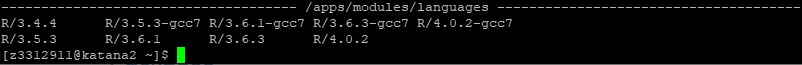

There is generally a ‘default’ version of any program (typically the most recent version), so usually the version does not need to be specified - however, it is better to do so.

You should include a command to load any required modules in your PBS script (See [Katana documentation](https://unsw-restech.github.io/restech-docs/software/environment_modules.html)).

It is also worth noting that some machine learning (and potentially other) packages in R require an active C++ (or other language) compiler - on a normal system this is generally not an issue, but on Katana you need to load the compiler manually, and typically specify a specific version of R (in the image above you will see that several versions of R are specific to GCC version 7).

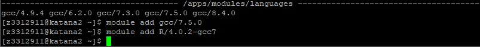

### Packages

In addition, when using R on Katana you will need to consider any packages required. Many packages are pre-installed on Katana (you can check which ones by creating an interactive job, loading R, and checking installed.packages()), but they may not be up to date. You can also request additional packages be installed by contacting the IT Service Centre with ‘Katana R Module installation’ in the subject line. However, it can potentially be faster to create a folder on Katana to save R packages, and define that folder using .libPaths() at the top of your syntax file. You can also add code to your file that checks whether packages are installed/need to be updated, and do so automatically:

```r
.libPaths("/home/z3312911/RPackages")[1] # Set R library path to a folder in Katana home drive
libs <- c("haven","mice","parallel") # Define all packages required
install <- !libs %in% installed.packages() | libs %in% old.packages() # Check if require install/update
if (any(install)) { # Install packages updated by previous step
  install.packages(libs[install])
}
lapply(libs, library, character.only = TRUE) # Load all required packages
```

However, occasionally package install fails, or R attempts to continue running code before install is completed, or install requires user input - so it is best to run an interactive job and install any required packages prior to running a batch job.